# Reproducible Research Peer assesement Project 1

**Loading and preprocessing the data**

```r
library(data.table)
data <- read.csv("activity.csv")
head(data)
```

```
##   steps       date interval
## 1    NA 2012-10-01        0
## 2    NA 2012-10-01        5
## 3    NA 2012-10-01       10
## 4    NA 2012-10-01       15
## 5    NA 2012-10-01       20
## 6    NA 2012-10-01       25
```

### Question 1 What is mean total number of steps taken per day?

**Aggregate steps per day, then make a histogram. It should be a normal distributed plot**

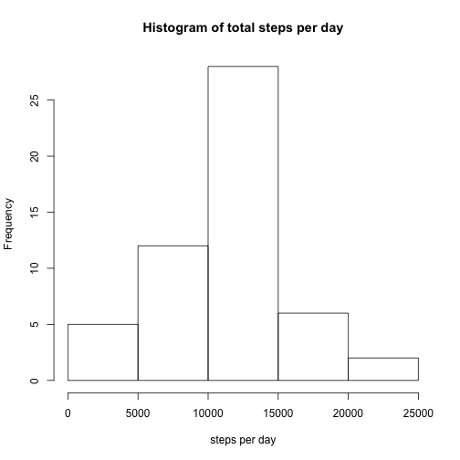

```r
dt <- data.table(data,key="date")
sumSteps <- dt[,lapply(.SD, sum), by=date]
hist(sumSteps$steps, main = "Histogram of total steps per day",xlab="steps per day")
```

**Calculate the mean and median total number of steps taken per day**

```r
mean <- mean(sumSteps$steps,na.rm=TRUE)
mean
```

```
## [1] 10766.19
```

```r
median <- median(sumSteps$steps,na.rm=TRUE)
median
```

```
## [1] 10765
```

#### *The mean of the total number of steps taken each day is 10766*

#### *The median of the total number of steps taken each day is 10765*

### Question 2 What is the average daily activity pattern?

**Make a time series plot of the 5-minute interval (x-axis) and the average number of steps taken, averaged across all days (y-axis)**

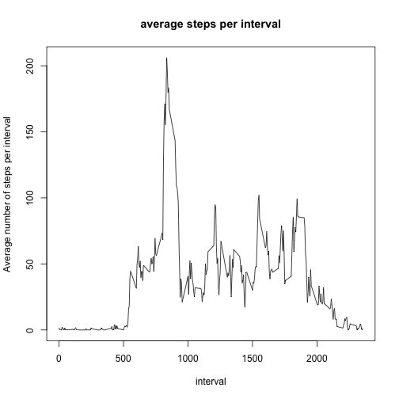

```r
dt2 <- data.table(data,key="interval")
Stepsby5min <- dt2[,lapply(.SD, mean,na.rm=TRUE), by=interval]
plot(Stepsby5min$interval,Stepsby5min$steps,type="l",xlab="interval", ylab="Average number of steps per interval",main="average steps per interval")
```

```r
max <- max(Stepsby5min$steps)
Stepsby5min$interval[which(Stepsby5min$steps==max)]
```

```
## [1] 835
```

#### *the 835 interval contians the maimum number of steps*

### Question 3 Imputing missing values

**1. The total number of missing values in the dataset**

```r
table(is.na(data$steps))
```

```
##
## FALSE  TRUE
## 15264  2304
```

```r
data2 <- as.data.frame(data)
data2[is.na(data)]<-mean/288
```

**Histogram of the total number of steps taken each day**

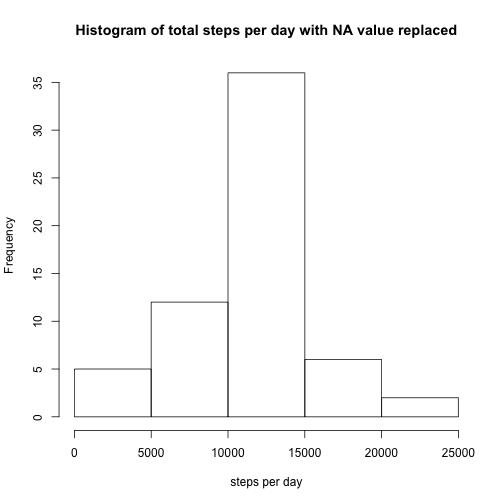

```r
dt2 <- data.table(data2,key="date")
sumSteps2 <- dt2[,lapply(.SD, sum), by=date]
hist(sumSteps2$steps, main = "Histogram of total steps per day with NA value replaced",xlab="steps per day")
```

**3.Calculate the mean and median total number of steps taken per day**

```r
mean <- mean(sumSteps2$steps,na.rm=TRUE)
mean
```

```
## [1] 10766.19
```

```r
median <- median(sumSteps2$steps,na.rm=TRUE)
median
```

```
## [1] 10766.19
```

### Question 4 Are there differences in activity patterns between weekdays and weekends?

**Convert the date into day of week, then reassign into two levels corresponding to either weekday or weekend.**

```r
date <- data[, "date"]
date <- as.Date(date)
dayofweek <- weekdays(date)
data <- cbind(data,dayofweek)
levels(data$dayofweek)
```

```
## [1] "Friday"    "Monday"    "Saturday"  "Sunday"    "Thursday"  "Tuesday"
## [7] "Wednesday"
```

```r
levels(data$dayofweek) <- c("Weekday","Weekday","Weekend","Weekend","Weekday","Weekday","Weekday")
levels(data$dayofweek)
```

```
## [1] "Weekday" "Weekend"
```

**Subset data by two different level**

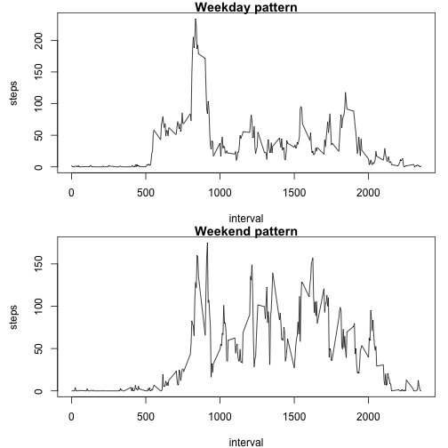

```r
weekday <- data[which(data$dayofweek=="Weekday"),]
weekend <- data[which(data$dayofweek=="Weekend"),]

weekday <- data.table(weekday,key="interval")
weekdaypattern <- weekday[,lapply(.SD, mean,na.rm=TRUE), by=interval]

weekend <- data.table(weekend,key="interval")
weekendpattern <- weekend[,lapply(.SD, mean,na.rm=TRUE), by=interval]

par(mfrow=c(2,1),mar=c(4.0,4.5,1,1))
plot(weekdaypattern$interval,weekdaypattern$steps,type="l",xlab="interval",main="Weekday pattern",ylab="steps")
plot(weekendpattern$interval,weekendpattern$steps,type="l",xlab="interval",main="Weekend pattern",ylab="steps")
```